# MXB344 Week 7 Slides

7 September 2016

## Welcome

MXB344 Lecture 7

## Housekeeping

- I'm nearly finished marking your assignment. Marks should be released tomorrow. I'll release your score on blackboard but I'll push feedback comments to your github repository.
- Today I want to revise some concepts commonly used incorrectly on your assignment.
- 2nd half of the lecture will be on Data Wrangling for Predictive Modelling.
- We'll finalise your assignment groups and discuss the assignment in detail in the prac. -We'll also return to the Titanic example.

## But first a plot.

## Which would you choose?

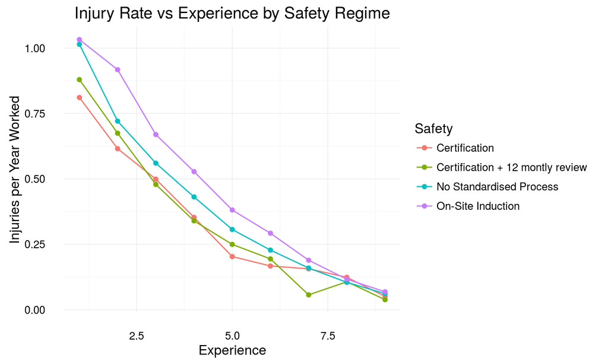

## For Your Next Assignment

### Models vs Visualisation

> **Visualisation** is a fundamentally human activity. A good visualisation will show you things that you did not expect, or raise new questions of the data. A good visualisation might also hint that you’re asking the wrong question and you need to refine your thinking. In short, visualisations can surprise you. However, visualisations don’t scale particularly well.

> **Models** are the complementary tools to visualisation. Models are a fundamentally mathematical or computation tool, so they generally scale well. Even when they don’t, it’s usually cheaper to buy more computers than it is to buy more brains. But every model makes assumptions, and by its very nature a model can not question its own assumptions. That means a model can not fundamentally surprise you.

-Hadley Wickham, *R for Data Science*

## Exploratory Analysis

- Don't under-value time spent on exploratory analysis. Your exploratory analysis will be your touch stone, and your sanity check.
- If the model you come up with does not agree with your exploratory visualisation this is a **BIG** red flag.
  - Do not move forward with the model until you have investigated.

## Significance

```
##
## Call:
## glm(formula = Injuries ~ Safety + Experience, family = poisson(link = "log"),
##     data = injuries, offset = log(Hours))
##
## Deviance Residuals:
##      Min        1Q    Median        3Q       Max
## -2.34895  -0.57690  -0.02576   0.56769   1.49838
##
## Coefficients:
##                                         Estimate Std. Error  z value
## (Intercept)                            -7.370288   0.069532 -105.999
## SafetyCertification + 12 montly review  0.033268   0.080852    0.411
## SafetyNo Standardised Process           0.227796   0.066567    3.422
## SafetyOn-Site Induction                 0.429796   0.068650    6.261
## Experience                             -0.331155   0.009656  -34.295
##                                        Pr(>|z|)
## (Intercept)                             < 2e-16 ***
## SafetyCertification + 12 montly review 0.680733
## SafetyNo Standardised Process          0.000622 ***
## SafetyOn-Site Induction                3.83e-10 ***
## Experience                              < 2e-16 ***
## ---
## Signif. codes:  0 '***' 0.001 '**' 0.01 '*' 0.05 '.' 0.1 ' ' 1
##
## (Dispersion parameter for poisson family taken to be 1)
##
##     Null deviance: 1345.622  on 35  degrees of freedom
## Residual deviance:   24.937  on 31  degrees of freedom
## AIC: 236.94
##
## Number of Fisher Scoring iterations: 4
```

## Significance

- If we changed the baseline safety category to On-Site Induction, everything would be significant according to the p-value.
- The p-value does not allow us to say something is "Significant in the model".
  - A covariate may have significant effect relative to the baseline.
  - p-values are not comparable between covariates. The p-value is a highly unstable measure.
- Significant amount of deviance explained is the only way to judge if a covariate should be in the model.
  - We can comapre freely between covariates this way as well.

## Continuous Predictors

```r
glm_frame <-tidy(glm_fit, conf.int = TRUE, exponentiate = TRUE)
glm_frame %>% select(term,estimate, conf.low,conf.high)
```

```
##                                     term     estimate     conf.low
## 1                            (Intercept) 0.0006296867 0.0005484185
## 2 SafetyCertification + 12 montly review 1.0338271477 0.8826803307
## 3          SafetyNo Standardised Process 1.2558292405 1.1041772262
## 4                SafetyOn-Site Induction 1.5369437878 1.3456221508
## 5                             Experience 0.7180941526 0.7045975066
##      conf.high
## 1 0.0007203068
## 2 1.2120400928
## 3 1.4335335166
## 4 1.7613267809
## 5 0.7317793209
```

- We're 95% confident that experience mutilplies injury rate by between 0.70 and 0.73 **per unit increase in experience**
- How would the injury rate decrease if we had zero churn for 3 years/months?

## Data Wrangling for Predictive Modelling

## Data Wrangling, Data Munging, Data Prep

- As you heard from BOQ, the bulk of the work in real-world data analysis is data preparation (80%!).
- What is the goal of data preparation?
- What are the challenges?
- What tools can we use to resolve them?

## Start with the end in mind

- Our target is [Tidy Data](http://vita.had.co.nz/papers/tidy-data.pdf)
- Tidy Data is simple to describe but can be subtle to recognise
- It has three simple rules:
1. Each variable must have its own column.
2. Each observation must have its own row.
3. Each value must have its own cell.

## Case study: Particle Simulation Study

- Background: Power simulation for particle size test
  - Power is probability that test will reject a false null hypothesis
- Is this tidy data?

| n | mean-2me;sd-5 | mean-2me;sd+5 | mean+2me;sd-5 | mean+2me;sd+5 |
| --- | --- | --- | --- | --- |
| 40 | 0.430 | 0.180 | 0.340 | 0.200 |
| 80 | 0.530 | 0.260 | 0.440 | 0.235 |
| 120 | 0.615 | 0.460 | 0.580 | 0.310 |
| 160 | 0.735 | 0.425 | 0.700 | 0.250 |
| 200 | 0.820 | 0.545 | 0.720 | 0.325 |
| 240 | 0.850 | 0.590 | 0.750 | 0.285 |
| 280 | 0.890 | 0.690 | 0.820 | 0.410 |
| 320 | 0.945 | 0.735 | 0.895 | 0.355 |
| 360 | 0.940 | 0.795 | 0.845 | 0.385 |
| 400 | 0.955 | 0.685 | 0.905 | 0.430 |

## Enter the Tidyverse

- [This is the tidyverse](https://github.com/hadley/tidyverse).
- `dplyr`, `ggplot2`, `broom`, `tidyr` etc are all geared toward tidy data.
- If something feels hard it's likely because your data isn't in the tidy form.

## Using ggplot2 with the power sim data

```r
power_sim %>%
  ggplot(aes(x = n)) +
  geom_line(aes(y= `mean-2me;sd-5`, colour=factor(1)))+
  geom_line(aes(y= `mean-2me;sd+5`, colour=factor(2)))+
  geom_line(aes(y= `mean+2me;sd-5`, colour=factor(3)))+
  geom_line(aes(y= `mean+2me;sd+5`, colour=factor(4)))
```

[output not shown]

- Still work to do to fix the legend…

## Introducing gather and spread

- `tidyr::gather()` and `tidyr::spread()` can help you rearrange your data into tidy form.
- `gather` takes a dataset and makes it narrow. Column headers turn into row values.
- `spread` makes a dataset wide. Row values turn into column headers.
  - Learning to use these functions effectively will make you look like a data wizard.

## Gathering the power sim data

```r
power_sim_gather <-
  power_sim %>%
  gather(key=?, value=?, ...)
```

## Using ggplot2 on the tidy power sim data

```r
power_sim_gather %>%
  ggplot(aes(x=n, y=power, colour=distribution)) +
  geom_line()
```

## Combining Data

- Sometimes you have multiple datasets you need to join together to create your tidy data set for analysis. (like your assignment!)
- Common scenarios where this arises:
  - Your data was extracted from a relational database (SQL): multiple tables
  - You need to append public data to your dataset. E.g weather, financial indicies.
  - Your data is published periodically. E.g. ABS stats, Financial reports etc.

## Introducing Joins

- `dplyr::bind_rows()`, `dplyr::bind_cols()` can work for trival cases where we have exactly the same number of rows or columns.
- For more complex cases we will need to consider a **join**.
- Before you can join two or more datasets you need to identify the **key** column(s).
  - These are columns that uniquely identify each row.

## Key example

What is the key?

```r
data("planes")
planes
data("flights")
flights
data("weather")
weather
```

## Join Example: Weather to Flights

Is departure delay associated with temperature?

```r
flights2 <- flights %>%
  select(year:day, hour, origin, dest, tailnum, carrier, dep_delay)

flight_weather <-
  flights2 %>%
  left_join(weather, by = c("year", "month", "day", "hour", "origin"))

ggplot(flight_weather, aes(x=temp,y=dep_delay)) +
  geom_point(alpha=0.2)
```

## Types of joins

- We'll walk though [the guide in R for Data Science](http://r4ds.had.co.nz/relational-data.html#understanding-joins).

## Issues arising when joining

- Missing values
  - Cannot fit a regression model with missing values
  - Options: Drop or impute and add indicator
  - Not expected to impute for assignment.
- Duplicate values
  - Can fit a regression model with duplicate observations, but this violates independent data assumption.
  - Effect esimtates will become nonsense.
  - Must remove!

## Making Comparable Features

- **Feaures** is a machine learning term for covariates.
- Feature engineering the the process of creating new covariates more from data in the dataset.
- A classic example are with date type columns.

## Case Study: Counting Customer contact

- A company with many brands was worried they were contacting their customers too much and upsetting them. Created fearures relating to recent contact to feed into marketing models.

```r
customer <- read_csv("customer.csv")
contact <- read_csv("contact.csv")
customer
```

```
## # A tibble: 3 × 5
##   customerID   age balance accept    date
##        <int> <int>   <int>  <int>  <date>
## 1          1    33   10876      0 9-09-16
## 2          2    55  350232      1 8-09-16
## 3          3    21  876520      0 7-09-16
```

```r
contact
```

```
## # A tibble: 19 × 5
##    contactID campaignID customerID contact_type           timestamp
##        <int>      <int>      <int>        <chr>               <chr>
## 1       1234          1          1        email 01/08/2016 12:00:00
## 2       1233          1          2          sms 02/08/2016 12:00:00
## 3       1236          2          1        email 03/08/2016 12:00:00
## 4       1236          2          2          sms 04/08/2016 12:00:00
## 5       1237          2          2          sms 05/08/2016 12:00:00
## 6       1238          2          2          sms 06/08/2016 12:00:00
## 7       1239          1          3        phone 07/08/2016 12:00:00
## 8       1378          1          3        email 08/08/2016 12:00:00
## 9       1379          1          3          sms 09/08/2016 12:00:00
## 10      1380          2          1        phone 10/08/2016 12:00:00
## 11      1381          2          3        email 11/08/2016 12:00:00
## 12      1382          2          1          sms 12/08/2016 12:00:00
## 13      1383          1          3        phone 13/08/2016 12:00:00
## 14      1384          1          2        email 14/08/2016 12:00:00
## 15      1385          2          2          sms 15/08/2016 12:00:00
## 16      1386          1          1          sms 16/08/2016 12:00:00
## 17      1387          2          1          sms 17/08/2016 12:00:00
## 18      1388          1          3        email 18/08/2016 12:00:00
## 19      1389          2          1        phone 19/08/2016 12:00:00
```

## First step: Join

```r
customer_contact <-
  left_join(contact, customer, by="customerID")
```

## Second step: Mutate

```r
customer_contact <-
  customer_contact %>%
  mutate(timestamp = as.Date(dmy_hms(timestamp)),
         date= dmy(date),
         date_diff = date-timestamp)
```

## Third step: Filter

```r
customer_contact <-
  customer_contact %>%
  filter(date_diff <= 30)
```

## Fourth step: Summarise

```r
customer_contact <-
  customer_contact %>%
  group_by(customerID) %>%
  summarise(n_contact = n()) %>%
  left_join(customer, by="customerID")
```

## Selecting Variables

## Variable selection heuristics

- By combination of feature engineering and large data you may end up with too many covariates to make sense of.
- Several heuristics can be employed to trim the number of columns down:
  - Identify and remove highly correlated columns. Usual cutoffs are 0.7 - agressive to 0.9 conservative.
  - Identify important variables and select the top n most important.